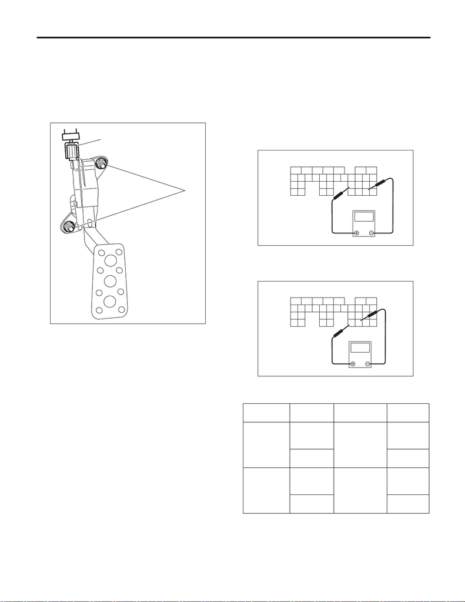

SP(STI)-4

Accelerator Pedal

SPEED CONTROL SYSTEMS

2. Accelerator Pedal

A: REMOVAL

1) Disconnect the ground cable from battery.

2) Disconnect the connector (A).

3) Remove the nut (B) securing accelerator pedal

assembly, and remove the accelerator pedal as-

sembly.

B: INSTALLATION

Install in the reverse order of removal.

Tightening torque:

7.5 N·m (0.8 kgf-m, 5.5 ft-lb)

C: DISASSEMBLY

NOTE:

The accelerator pedal cannot be disassembled.

D: INSPECTION

1. CHECK ACCELERATOR PEDAL SEN-

SOR AREA (METHOD WITH CIRCUIT

TESTER)

1) Remove the glove box. <Ref. to EI-63, REMOV-

AL, Glove Box.>

2) Turn the ignition switch to ON. (engine OFF)

3) Measure the voltage between ECM connector

terminals.

• Main sensor side

• Sub sensor side

4) After inspection, install the related parts in the

reverse order of removal.

SP-02143

(B)

(A)

(A) To ECM connector

(A) To ECM connector

Accelerator

pedal sensor

Accelerator

pedal

Terminal No. Standard

Main

Not

depressed

(full closed)

23 (+) and 29 (–)

0.4 — 1.0 V

Depressed

(full opened)

2.4 — 3.7 V

Sub

Not

depressed

(full closed)

31 (+) and 30 (–)

0.3 — 1.1 V

Depressed

(full opened)

2.3 — 3.8 V

SP-02078

V

(A)

8

21

9

43

10

28

23

31

SP-02079

V

(A)

8

21

9

43

10

28

23

31

[figure not shown]

SP(STI)-5

Accelerator Pedal

SPEED CONTROL SYSTEMS

2. CHECK ACCELERATOR PEDAL SEN-

SOR AREA (METHOD WITH SUBARU SE-

LECT MONITOR)

1) Turn the ignition switch to ON. (engine OFF)

2) Read the accelerator pedal opening angle signal

and voltage of accelerator pedal sensor using Sub-

aru Select Monitor. <Ref. to EN(STI)(diag)-36, DIS-

PLAY CURRENT ENGINE DATA (NORMAL

MODE), OPERATION, Subaru Select Monitor.>

3. OTHER INSPECTIONS

1) Check that the accelerator pedal does not have

deformation, cracks or damage.

2) Check for smooth operation when the accelera-

tor pedal is depressed.

3) Check if the accelerator pedal returns to its orig-

inal position smoothly when the pedal is released.

Accelerator pedal

sensor

Accelerator pedal

opening angle signal

Standard

Main

0.0% 0.4 — 1.0 V

100.0% 2.4 — 3.7 V

Sub

0.0% 0.3 — 1.1 V

100.0% 2.3 — 3.8 V

[figure not shown]

SP(STI)-6

Accelerator Pedal

SPEED CONTROL SYSTEMS

[figure not shown]

IGNITION

IG(STI)

Page